# The Des Plaines Rivers’ Flooding Problem

Anna Madison Burns

10/14/2020

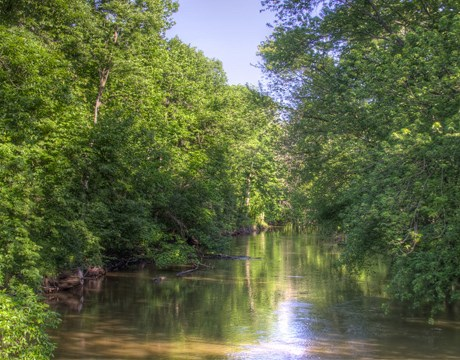

Figure 1. The Des Plaines River in Lake County, Illinois (Lake County Forest Preserve)

Water flowing freely across Oak Spring Road has become a common sight in Libertyville. After rain, it has become normal to expect the Des Plaines River to have flooded the bridge underpasses along the River Trail, rendering them unusable for weeks. Even worse, in the past years there have been several major flooding events that have impacted homes and businesses across Libertyville as the lakes and rivers are unable to accomodate the excess precipitation. This is a cause for concern for anyone who lives and works in Libertyville – will my home or business be in danger of flooding the next time it rains? Will the Des Plaines River flooding its banks become a common occurence?

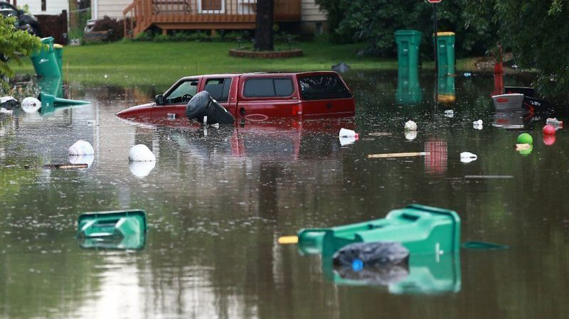

Figure 2. Des Plaines River floods, June 2018 (Moran).

## A brief ecological and social history of northern Illinois

Northern Illinois is a prairie-forest glaciated landscape with a historically high-organic-content loess soil that has been eroded by extensive industrial agriculture over the past 150 years to a clay-dense soil B-horizon (Knox). The region is populated largely by towns with populations under 30,000 who work both in local industry and in commuting to Chicago or Milwaukee. Agriculture is also common in the area, with large fields of corn and soy as well as smaller produce farms. Calculated for the 1981-2010 climate averages, the Antioch Illinois Weather Service Station reports that the mean January temperature is 21.9 F, with an average of 28.5 days below 32 degrees and 5.5 days below 0 degrees (without accounting for windchill). In contrast, the average July temperature is 73.5 F, with an average of 3.5 days above 90 F. The annual mean precipitation for the region is 36.7 inches (the majority of which tends to fall in the summer months), with an annual mean snowfall of 42.7 inches.

## How will northern Illinois be impacted by climate change?

Although global warming will cause an overall increase in global temperatures, specific regions will be impacted in a myriad of different ways. One of the most significant ways that climate change will impact northern Illinois is with shifts in precipitation. Frankson and Kunkel (2017) found that there has already been a state-wide increase in the number and severity of rainstorms. Additionally, Cherkauer and Sinha (2010) discuss how the bulk of annual precipitation is likely going to shift from the summer to the spring. Further, that rain will likely be condensed into rainstorms, or periods when there is heavy rainfall over a short period of time.

These shifts in percipitation trends caused by climate change will compound problems that have already been caused by historic land use changes. Knox (2001) describes how the original organically-rich loess soil has largely been eroded to a clay-dense soil due to early agricultural practices. This clay-heavy soil is less permeable, so less water can soak into it and more is forced to run off into the rivers and lakes. The result of this is that the entire watershed is less resilient, because the already overburdened rivers have to take on the water that the soil no longer can. A primary result of this will be an increase in high stream flow days of up to 22-31%, indicating that more water will enter the watersheds rather than being absorbed by the soil (Cherkauer and Sinha, 2014).

However, soil erosion from land use changes will be the least of our worries in the years to come. Although land use changes have likely driven historic changes in the amount of water entering rivers and lakes, in the future the primary driver for these issues will likely be climate change. This shift is detailed in Frans et. al (2013), who conducted a hydrologic model study of the Upper Mississippi River Valley (including northern Illinois). His team determiend that in a modern application, upwards of 90 percent of changes in water runoff in the region were due to climate change-driven factors even in areas that experienced land use change. This is not to suggest that soil erosion has not impacted water runoff in the past century, only that the changes to the soil which cause these changes have already taken place – the clay-filled soil B-horizon has already been exposed, but we are only just beginning to experience the impact of climate change.

## What does this mean for northern Illinois communities?

The increase in stream flow rates during peak flow events over the past sixty years suggests that the Des Plaines River watershed is highly impacted by rainstorms, which are likely to increase in the region due to climate change. This information tells us that the Des Plaines River lacks resilience to climate change, or the ability to remain stable through environmental changes. This could have serious impacts on the populations of Lake County which fall along the River, including Libertyville, throughout the 21st century.

One of the primary ways that the Des Plaines River’s lack of resilience could impact Lake County populations is by overwhelming combiend stormwater-sewage systems, which are common in the Great Lakes Region (Patz, 2014). If the volume of water exceeds the holding capacity of the Des Plaines River watershed and causes flooding, in many areas this excess water is handled by stormwater systems that are combined with sewage systems. When these in turn are overwhelmed, combined water and sewage flood out, increasing instances of waterborne illnesses due to sewage contamination. A further impact could be increased flooding events when the Des Plaines River is overwhelmed by the volume of water, like those that have been occuring annually in Libertyville, causing significant damage to homes and properties. Both increased instances water-borne illnesses and property damage would most heavily impact the vulernable populations in Lake County, as the costs of repairing a home or recieving medical aid for illness are often very high.

## How will I be impacted?

If any of this information concerns you, or leads you to fear for your health, home, or business – you are a climate activist! Even if you have never considered yourself to be one before, climate activism doesn’t necessarily mean going vegan or putting solar panels on your house. If you are worried about the impacts that a shifting climate will have on your life, and wonder what you can do to stop or lessen those impacts, you are now a climate activist. As a climate activist, it will be necessary to understand the ways that climate change could impact you. Seeing the data of environmental change yourself can help to dispell any of the healthy skepticism you may have (after all, I haven’t shown any proof for my claims yet!). If you don’t necessarily believe me yet, that is all right. Read on to see for yourself the data that supports my claim of increased water volume in the Des Plaines River watershed during its fastest annual flows.

# Where is the proof?

The best way to analyze the severity of an environmental threat is by viewing the data yourself. Although Libertyville does not have robust historical precipitation data; however, our neighbors in Antioch kept a comprehensive account of daily weather measurements between 1901 and 2008. This data is a useful proxy for understanding precipitation trends in Libertyville, because Antioch is similar both geographically and climactically. I obtained data on precipitation levels from the National Oceanic and Atmospheric Administration (NOAA)’s Climate Data Online database, which is free to access for the public and contains historic records of local weather.

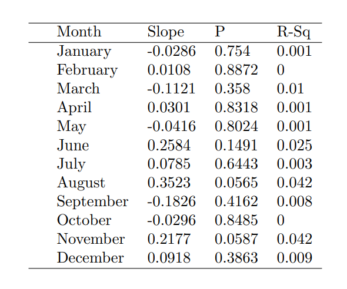

Figure 3. Antioch, IL Monthly Precipitation Trends (1901 to 2008)

In contrast, the U.S. Geological Survey’s National Water Information System Des Plaines River metering station, where the flow and the height of the river is measured in Russell, IL (approximately ten miles from Antioch) displays significant trends in streamflow levels during peak flow events from 1960 to 2019. This data is collected in coordination of Illinois Department of Natural Resources’ Office of Water Resources, near the Illinois-Wisconsin border and the Sterling Lake system. The river narrows significantly a few miles past Russell in the Wisconsin portion of the watershed, but is at a representative width for the Lake County Des Plaines River watershed by the time it reaches the meter station in Russell, IL. This therefore rules out the problem that the river is narrower in this section than downstream in Libertyville, causing a faster water flow as the same volume of water needs to navigate a narrower outlet.

This data contains the streamflow (cubic feet per second) and discharge levels (feet) during the peak annual streamflow events for every year between 1960 and 2019. The streamflow levels was plotted against time, and similarly to with the precipitation data a linear regression model was applied to the data. Once again, this linear regression operated at a 5% confidence level, with the null hypothesis that streamflow during peak flow events had not changed over time. Because there was a lot of variation in the data, the analysis benefitted from a logarithmic transformation. The best fit line and plotted data is included in Figure 4.

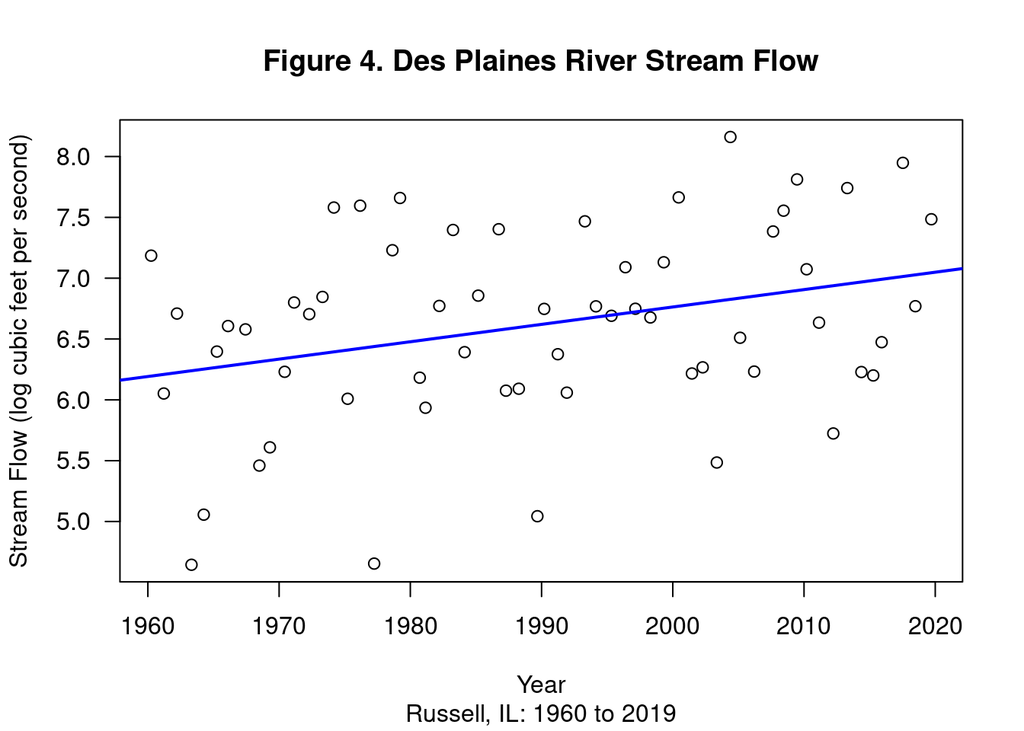

The linear regression had a p-value of 0.016, meaning that the null hypothesis that there was no correlation between peak streamflow levels and time could be comfortably rejected and there is evidence to suggest that streamflow levels during peak flow events have increased between 1960 and 2019. Although the correlation is low with an adjusted R-squared of 0.1 (meaning that approximately 10 percent of the variation in peak annual stream flow levels can be explained by the variation in the date), because natural phenomenon have so many conflicting variables this level of correlation is satisfactory – it is highly unlikely that a high amount of the correlation would be from just one factor. Although the data fails the independence assumption for linear modeling (because the datapoints fall on sequential dates), once a logarithmic transformation was applied the data was sufficiently homoskedastic, normal, and linear for the model to still be used. In other words, the data was sufficiently non-alarming, falling along a regular trend with no worrisome outliers to skew the results of the model.

## Skeptic claims: How can we know it’s climate change?

Skeptics may question the validity of my assertion that Lake County will be vulnerable to rainstorms due to the lack of resilience of the Des Plaines watershed on two grounds. First, that northern Illinois is not expected to see an immediate increase in precipitation levels; second, that precipitation levels have not been shown to increase in the region over the past century in spite of rising global temperatures. However, this data does not describe overall levels in precipitation, but rather rainstorms. Cherkauer and Sinha (2010) describe that while precipitation levels may not increase immediately in northern Illinois, the bulk of the rainfall will likely shift from the summer to the spring. Furthermore, this rainfall is more likely to be condensed into storms, which will have more of a damaging imapct on the Des Plaines watershed than rain events over a long period of time would.

# Conclusions

This data directly reflects Cherkauer and Sinha’s analysis that peak stream flow events will become more severe across the Upper Mississippi River Valley. Although this is partially a reflection of the land use change described by Knox (2001), it is likely further impacted by global climate change as detailed in Frans et al. (2013). These changes indicate the possibility of global climate change having severe human health and economic impacts on the northern Illinois region. Some of these impacts can be mitigated by updating sewage-stormwater infrastructure to prevent overflows, and informing citizens about protecting their homes and businesses from flooding. However, to fully stem the impacts of climate change on northern Illinois, a transformation of the economy’s reliance on fossil fuels will be necessary in order to stem the worst effects of global climate change on northern Illinois’ most vulnerable citizens.

Residents of Libertyville have been unable to avoid the recent truth of the Des Plaines River flooding after rainstorms, heavily impacting life in the village. Now you are armed with data that demonstrates the severity of this problem, and as a citizen climate activist hoping to protect your family’s health and home, you are at a powerful point from which to start advocating for changes that will lessen the impacts of climate change on you and yours. Getting involved in the monthly public Village Board meetings is a good place to start – make sure that issues like watershed restoration are on the table, which could decrease the vulnerability of the Des Plaines River to flooding. Share this information with your neighbors, so that the whole village is informed on these issues and how they are impacted by them. Libertyville’s strength lies in its sense of community; let’s leverage our community to create change.

# Works Cited

Angel, J. (2020). “Official 1981-2010 Climate Normals.” Illinois State Water Survey. Accessed 25 September, 2020 from https://www.isws.illinois.edu/statecli/newnormals/normals.USC00110203.txt.

Cherkauer, K.A. & Sinha, T. (2010). “Hydrologic impacts of projected future climate change in the Lake Michigan region.” Journal of Great Lakes Research, 36, pp. 33-50. DOI: 10.1016/j.jglr.2009.11.012.

Frankson, R., K. Kunkel, S. Champion, B. Stewart, D. Easterling, B. Hall, and J. R. Angel. (2017). “Illinois State Climate Summary.” NOAA Technical Report NESDIS 149-IL (4).

Frans, C., et al. (2013). “Are climactic or land cover changes the dominant cause of runoff trends in the Upper Mississippi River Basin?” Geophysical Research Letters, 40, pp. 1104-1110. DOI: 10.1002/grl.50262.

Knox, J.C. (2001). “Agricultural influence on landscape sensitivity in the Upper Mississippi River Valley.” Catena, 42(2-4), pp. 193-224. DOI: 10.1016/S0341-8162(00)00138-7.

Lake County Forest Preserve. (n.d.). “Des Plaines River Trail and Greenway.” Accessed 13 October, 2020 from https://www.lcfpd.org/dprt/.

Moran, D. (2018). “Moran: A year after floods, rivers are running low – And we hope they stay that way.” Chicago Tribune. Accessed 13 October, 2020 from https://www.chicagotribune.com/suburbs/lake-county-news-sun/opinion/ct-lns-lake-county-flooding-anniversary-st-0711-story.html.

Patz, J. (2014). “Health.” In J.A. Winkler, et al. (Eds.), Climate change in the Midwest: A synthesis report for the National Climate Assessment, pp. 188-196. Island Press.